# Exploring the Governement shutdown data

Let's start with trying to make sense of data… From Toms' script I knwo that e have 3 tables: t1 t4 and t3a.

t1 seems to be the operating cash balance t4 is the Federal Tax deposit t3 is the Public Dept transaction.

Rememebr is always good to read any doc availble that explains the data: from the documentation: T1 explains “how much money does Uncle Sam have in his checking account on any given day”“

Now I want to explore a little bit the data. TO chekc if they have the same data range for instance. Let's use some SQL.

```r
library(sqldf)
```

```r
library(ggplot2)
library(colorspace)
library(scales)
setwd("/Users/carlotorniai/Dropbox/Zipfian/git/government-shutdown")
# Load all of the tables into R
.tables <- sqldf("SELECT tbl_name FROM sqlite_master", dbname = "treasury_data.db")$tbl_name
for (.table in .tables) {
    if (!(.table %in% ls())) {
        .sql <- paste("SELECT * FROM", .table)
        assign(.table, sqldf(.sql, dbname = "treasury_data.db"))
    }
}
# Let's try to experiment with some queries..
print("Min date in T1")
```

```
## [1] "Min date in T1"
```

```r
print(sqldf("SELECT MIN(date) FROM t1;"))
```

```
##    MIN(date)
## 1 2005-06-09
```

```r
print("Max date in T1")
```

```
## [1] "Max date in T1"
```

```r
print(sqldf("SELECT MAX(date) FROM t1;"))
```

```
##    MAX(date)
## 1 2013-10-15
```

```r
brewerplot <- function(palette) {
    p + scale_fill_brewer(palette = palette) + opts(title = palette)
}
brewerplot("Pastel1")
```

```
## Error: object 'p' not found
```

```r
# Let's try to experiment with some queries..
print("Min date in T4")
```

```
## [1] "Min date in T4"
```

```r
print(sqldf("SELECT MIN(date) FROM t4;"))
```

```
##    MIN(date)
## 1 2005-06-09
```

```r
print("Max date in T4")
```

```
## [1] "Max date in T4"
```

```r
print(sqldf("SELECT MAX(date) FROM t4;"))
```

```
##    MAX(date)
## 1 2013-10-15
```

So it seems we have the same date range. So in T1 we have the type of accounts for operating cash balance. These are under the column: account or account row. Let's check the variosu types of accounts

```r
sql <- "SELECT DISTINCT account from t1;"
print(sqldf(sql))
```

```
##                                   account
## 1                 Federal Reserve Account
## 2  Tax and Loan Note Accounts ( Table V )
## 3                 Total Operating Balance
## 4         Supplementary Financing Program
## 5           Financial Institution Account
## 6 Short Term Cash Investments ( Table V )
```

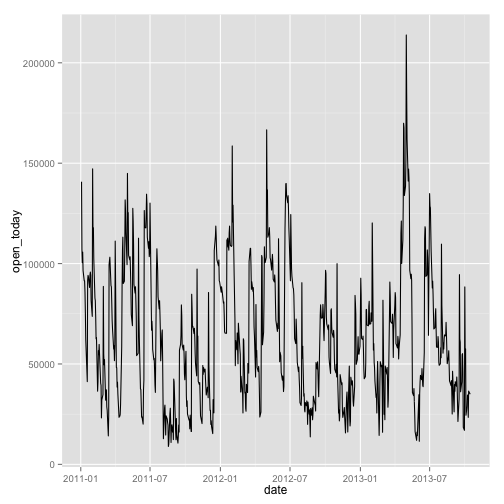

```r
# Let's get the data first
sql <- "select * from t1 where account =\"Federal Reserve Account\" and date > \"2011-01-01\""
federal_account_trend = sqldf(sql)
# Let's transform the dates in date
federal_account_trend$date <- as.Date(federal_account_trend$date)
# Let's plot and ad some axis
ggplot(federal_account_trend, aes(x = date, y = open_today)) + geom_line()
```

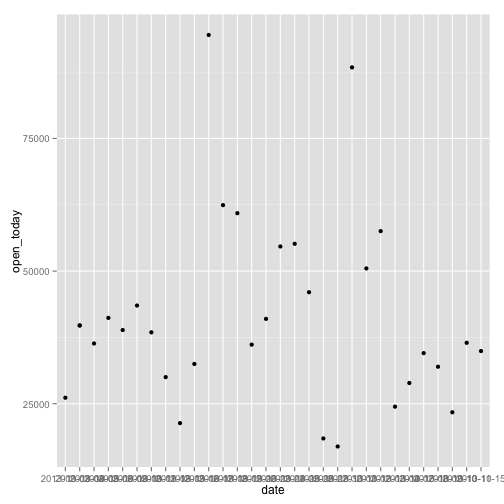

```r
sql <- "select * from \"t1\" where date > \"2013-09-01\" and account = \"Federal Reserve Account\""
d <- sqldf(sql)
qplot(x = date, y = open_today, data = d, geom = "point")
```

Ok let's try now ti have acomulative sum per year and visualize it as a barpolt I have a filed which is year… Also I have the open_fy which indicates for each account the opening balance for fiscal year. So to have a rough trand over the years I can get just this value for each year in the table.

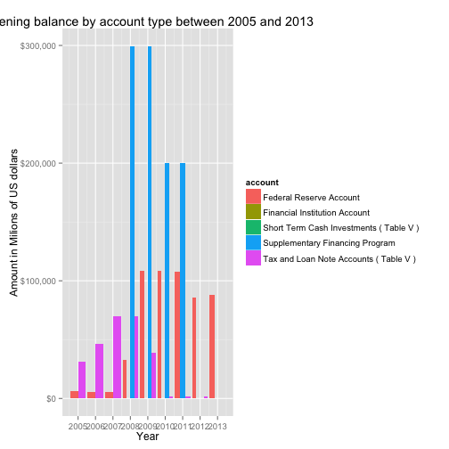

```r
# Ok now i try to plot the different types of account per year one next to
# the ohter.
accounts <- sqldf("select distinct account, open_fy, year from t1 where is_total==0 and account <>\"Total Opening Balance\"")
p1 <- ggplot(accounts, aes(x = year, y = open_fy, group = account, fill = account)) +
    geom_bar(position = "dodge", stat = "identity") + xlab("Year") + ylab("Amount in Milions of US dollars") +
    labs(title = "Opening balance by account type between 2005 and 2013")

p2 <- p1 + scale_y_continuous(labels = dollar) + scale_x_continuous(breaks = 2005:2013)
# Here I want to try to use the scale on Y to display the dollar Now I want
# to add each entry
p2
```

We can see how during the big financial crisis (2008-2011) everything went "off scale”. In particular notice the Supplementary Financing Program.

Now I want to go and see where this money went. In order to do this I want to analyze the data of the withdrowals of money in table2.

Remeber that table t2 reports “what did Uncle Sam spend money on today, and how much” So le'ts have a closer look at table 2.

Please note the description of the table about the is_total and is_net:

**is_total**: Binary flag field indicating whether the deposit or withdrawal represents a total figure (1) or sub-component that adds up to the total (0). Exclude rows marked (1) from sum queries to prevent double-counting.

**is_net**: Binary flag indicating whether the item represents a net of deposits and withdrawals (1) or just deposits or withdrawals (0). Treasury presents some programs separately on both sides of the ledger but nets others together, or lists them separately but later on begins netting them together. Use this flag to disambiguate between the two.

So here I need to pay more attention to execute my query.

```r
# The query below works
expenses_2005_total <- sqldf("select date, account, item, today from t2 where is_total==0 and year=2005 and transaction_type==\"withdrawal\"")

expenses_2005 <- sqldf("select  account, item, sum(today) as total from t2 where is_total==0 and year=2005 and transaction_type==\"withdrawal\" group by account, item order by fytd desc limit 20")

# Now let's get the data we are interesred in There is certaintly a better
# way to do this within a for loop
expenses_2008 <- sqldf("select  account, item, sum(today) as total from t2 where is_total==0 and year=2008 and transaction_type==\"withdrawal\" group by account, item order by fytd desc limit 20")

expenses_2009 <- sqldf("select  account, item, sum(today) as total from t2 where is_total==0 and year=2009 and transaction_type==\"withdrawal\" group by account, item order by fytd desc limit 20")

expenses_2010 <- sqldf("select  account, item, sum(today) as total from t2 where is_total==0 and year=2010 and transaction_type==\"withdrawal\" group by account, item order by fytd desc limit 20")

expenses_2011 <- sqldf("select  account, item, sum(today) as total from t2 where is_total==0 and year=2011 and transaction_type==\"withdrawal\" group by account, item order by fytd desc limit 20")
```

```r
expenses_2005 <- sqldf("select  account, item, sum(today) as total from t2 where is_total==0 and year=2005 and transaction_type==\"withdrawal\" and item not in (\"Public Debt Cash Redemp ( Table III B )\", \"Transfers to Federal Reserve Account Table V\") group by account, item order by fytd desc limit 10")

# Now let's get the data we are interesred in There is certaintly a better
# way to do this within a for loop
expenses_2008 <- sqldf("select year, account, item, sum(today) as total from t2 where is_total==0 and year=2008 and transaction_type==\"withdrawal\" and item not in (\"Public Debt Cash Redemp ( Table III B )\", \"Transfers to Federal Reserve Account Table V\", \"Transfers to Depositaries\") group by account, item order by fytd desc limit 10")

expenses_2009 <- sqldf("select year, account, item, sum(today) as total from t2 where is_total==0 and year=2009 and transaction_type==\"withdrawal\" and item not in (\"Public Debt Cash Redemp ( Table III B )\", \"Transfers to Federal Reserve Account Table V\", \"Transfers to Depositaries\") group by account, item order by fytd desc limit 10")

expenses_2010 <- sqldf("select year, account, item, sum(today) as total from t2 where is_total==0 and year=2010 and transaction_type==\"withdrawal\" and item not in (\"Public Debt Cash Redemp ( Table III B )\", \"Transfers to Federal Reserve Account Table V\", \"Transfers to Depositaries\") group by account, item order by fytd desc limit 10")

expenses_2011 <- sqldf("select year, account, item, sum(today) as total from t2 where is_total==0 and year=2011 and transaction_type==\"withdrawal\" and item not in (\"Public Debt Cash Redemp ( Table III B )\", \"Transfers to Federal Reserve Account Table V\", \"Transfers to Depositaries\") group by account, item order by fytd desc limit 10")
```

[output not shown]

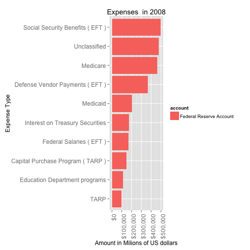

```r
# Now let's plot this in some meaningful graph let's start with 2008
expenses_2008 <- expenses_2008[complete.cases(expenses_2008), ]
# sort_expenses_2008 <- expenses_2008[order(expenses_2008$total, decreasing
# = TRUE) , ]
expenses_2008 <- transform(expenses_2008, item = reorder(item, total))
exp_2008 <- ggplot(expenses_2008, aes(x = item, y = total, fill = account)) +
    geom_bar() + xlab("Expense Type") + ylab("Amount in Milions of US dollars") +
    labs(title = "Expenses  in 2008") + theme(axis.text.x = element_text(angle = 90,
    hjust = 1, size = 12)) + theme(axis.text.y = element_text(hjust = 1, size = 12)) +
    scale_y_continuous(labels = dollar) + coord_flip()
exp_2008
```

[output not shown]

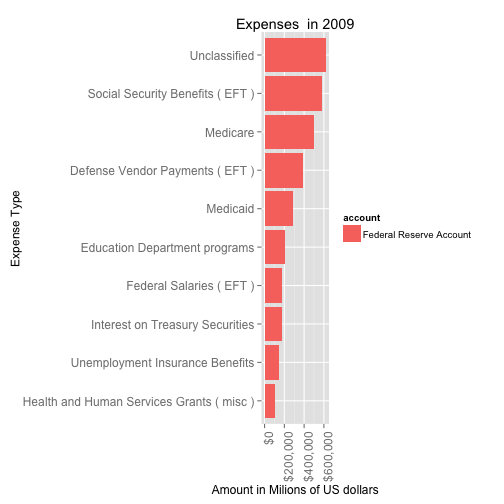

```r
# Now I just ant to have the legend be nicer but for now let's just don't
# worry about

# Now let's plot this in some meaningful graph let's start with 2009
expenses_2009 <- expenses_2009[complete.cases(expenses_2009), ]

expenses_2009 <- transform(expenses_2009, item = reorder(item, total))
exp_2009 <- ggplot(expenses_2009[1:10, ], aes(x = item, y = total, fill = account)) +
    geom_bar() + xlab("Expense Type") + ylab("Amount in Milions of US dollars") +
    labs(title = "Expenses  in 2009") + theme(axis.text.x = element_text(angle = 90,
    hjust = 1, size = 12)) + theme(axis.text.y = element_text(hjust = 1, size = 12)) +
    scale_y_continuous(labels = dollar) + coord_flip()
exp_2009
```

[output not shown]

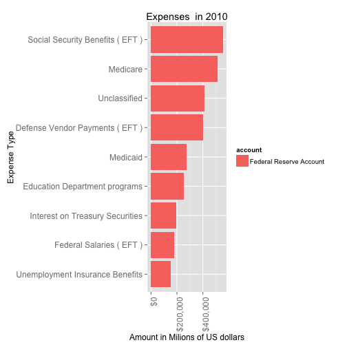

```r
expenses_2010 <- expenses_2010[complete.cases(expenses_2010), ]

expenses_2010 <- transform(expenses_2010, item = reorder(item, total))
exp_2010 <- ggplot(expenses_2010, aes(x = item, y = total, fill = account)) +
    geom_bar() + xlab("Expense Type") + ylab("Amount in Milions of US dollars") +
    labs(title = "Expenses  in 2010") + theme(axis.text.x = element_text(angle = 90,
    hjust = 1, size = 12)) + theme(axis.text.y = element_text(hjust = 1, size = 12)) +
    scale_y_continuous(labels = dollar) + coord_flip()
exp_2010
```

[output not shown]

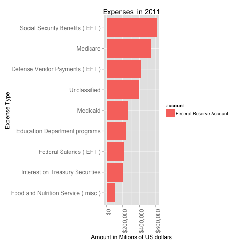

```r
expenses_2011 <- expenses_2011[complete.cases(expenses_2011), ]

expenses_2011 <- transform(expenses_2011, item = reorder(item, total))
exp_2011 <- ggplot(expenses_2011, aes(x = item, y = total, fill = account)) +
    geom_bar() + xlab("Expense Type") + ylab("Amount in Milions of US dollars") +
    labs(title = "Expenses  in 2011") + theme(axis.text.x = element_text(angle = 90,
    hjust = 1, size = 12)) + theme(axis.text.y = element_text(hjust = 1, size = 12)) +
    scale_y_continuous(labels = dollar) + coord_flip()
exp_2011
```

[output not shown]

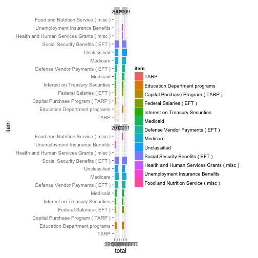

```r
# Let's try with the merging still it doesnt' work.  Let's try to figure
# this out later Now I want to show all this in the same order
expenses_08_09 <- rbind(expenses_2008, expenses_2009)
expenses_08_09_10 <- rbind(expenses_08_09, expenses_2010)
expenses_08_11 <- rbind(expenses_08_09_10, expenses_2011)
comulative_top_expenses <- ggplot(expenses_08_11, aes(x = item, y = total, fill = item)) +
    geom_bar() + facet_wrap(~year) + scale_y_continuous(labels = dollar) + theme(axis.text.x = element_text(size = 11)) +
    coord_flip()
comulative_top_expenses
```

```r
# I may want to try later on to visualize one on top of the other...
```

Then I want to ask: what did it change with government shoutdown in the first two weeks of October 2013?

Make sure to choose the right tables and the proper filtering of results.

So now I want just to have a sense of which expenses were cut in the first two weeks of October. I want first have a look at some other years and have what was paid there.

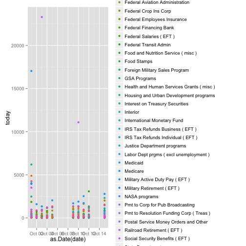

```r
# October 2012
expenses_october_2012 <- sqldf("select  date, account, item, today  from t2 where is_total==0 and year=2012 and transaction_type==\"withdrawal\" and item not in (\"Public Debt Cash Redemp ( Table III B )\", \"Transfers to Federal Reserve Account Table V\", \"Transfers to Depositaries\") and month=10 and day<16")
# Let's remove the Nas
expenses_october_2012 <- expenses_october_2012[complete.cases(expenses_october_2012),
    ]
# Also I want to get rid of every value that is 0 or below )
expenses_october_2012_pos <- subset(expenses_october_2012, today > 0)
exp_oct_2012 <- ggplot(expenses_october_2012_pos, aes(x = as.Date(date), y = today)) +
    geom_point(aes(colour = item))
exp_oct_2012
```

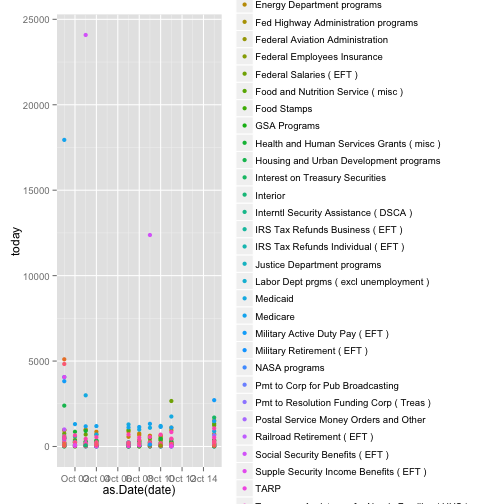

```r
# October 2013
expenses_october_2013 <- sqldf("select  date, account, item, today  from t2 where is_total==0 and year=2013 and transaction_type==\"withdrawal\" and item not in (\"Public Debt Cash Redemp ( Table III B )\", \"Transfers to Federal Reserve Account Table V\", \"Transfers to Depositaries\") and month=10 and day<16")
# Let's remove the Nas
expenses_october_2013 <- expenses_october_2013[complete.cases(expenses_october_2013),
    ]
# Also I want to get rid of every value that is 0 or below )
expenses_october_2013_pos <- subset(expenses_october_2013, today > 0)
exp_oct_2013 <- ggplot(expenses_october_2013_pos, aes(x = as.Date(date), y = today)) +
    geom_point(aes(colour = item))
exp_oct_2013
```

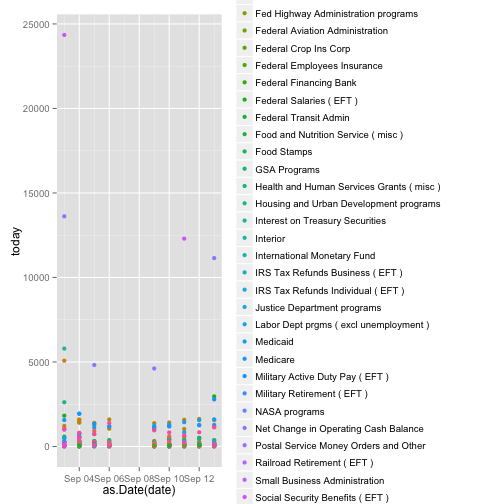

```r
# September 2013
expenses_sept_2013 <- sqldf("select  date, account, item, today  from t2 where is_total==0 and year=2013 and transaction_type==\"withdrawal\" and item not in (\"Public Debt Cash Redemp ( Table III B )\", \"Transfers to Federal Reserve Account Table V\", \"Transfers to Depositaries\") and month=9 and day<16")

# Let's remove the Nas
expenses_sept_2013 <- expenses_sept_2013[complete.cases(expenses_october_2013),
    ]
# Also I want to get rid of every value that is 0 or below )
expenses_sept_2013_pos <- subset(expenses_sept_2013, today > 0)
exp_sept_2013 <- ggplot(expenses_sept_2013_pos, aes(x = as.Date(date), y = today)) +
    geom_point(aes(colour = item))
exp_sept_2013
```

In this way we can't see any difference.

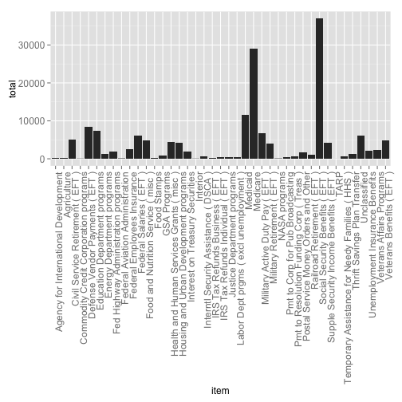

```r
# Now let's group the total for the Month of OCtober 2013
oct_2013_exp_sum <- sqldf("select  date, account, item, sum(today) as total  from t2 where is_total==0 and year=2013 and transaction_type==\"withdrawal\" and item not in (\"Public Debt Cash Redemp ( Table III B )\", \"Transfers to Federal Reserve Account Table V\", \"Transfers to Depositaries\") and month=10 and day<16 group by item")

# Now let's group the total for the month of October 2012
oct_2012_exp_sum <- sqldf("select  date, account, item, sum(today) as total  from t2 where is_total==0 and year=2012 and transaction_type==\"withdrawal\" and item not in (\"Public Debt Cash Redemp ( Table III B )\", \"Transfers to Federal Reserve Account Table V\", \"Transfers to Depositaries\") and month=10 and day < 16 group by item")

pos_oct_2013 <- subset(oct_2013_exp_sum, total > 0)
pos_oct_2012 <- subset(oct_2012_exp_sum, total > 0)

g_oct_2013 <- ggplot(pos_oct_2013, aes(x = item, y = total)) + geom_bar(stat = "identity") +
    theme(axis.text.x = element_text(angle = 90, hjust = 1, size = 12)) + theme(axis.text.y = element_text(hjust = 1,
    size = 12))
g_oct_2013
```

[output not shown]

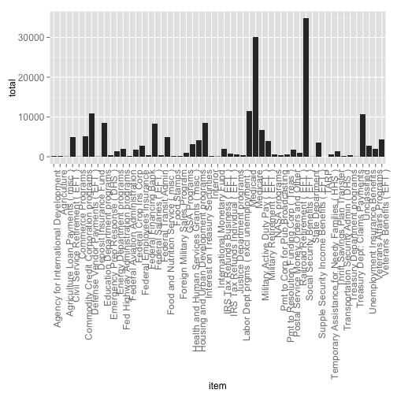

```r
g_oct_2012 <- ggplot(pos_oct_2012, aes(x = item, y = total)) + geom_bar() +
    theme(axis.text.x = element_text(angle = 90, hjust = 1, size = 12)) + theme(axis.text.y = element_text(hjust = 1,
    size = 12))
g_oct_2012
```

Well besides the value one thing is clear: There are “less” bills payd

```r
exp_2012 <- data.frame(expenses_october_2012)
items_2012 <- exp_2012$item

exp_2013 <- data.frame(expenses_october_2013)
items_2013 <- exp_2013$item
lost_items <- setdiff(items_2012, items_2013)
lost_items
```

```
##  [1] "Emergency Prep Response ( DHS )"
##  [2] "Federal Crop Ins Corp"
##  [3] "Federal Financing Bank"
##  [4] "International Monetary Fund"
##  [5] "Treasury Department programs"
##  [6] "Foreign Military Sales Program"
##  [7] "Commerce Programs"
##  [8] "Federal Transit Admin"
##  [9] "Treasury Dept: Claims Payments"
## [10] "Agriculture Loan Payments ( misc )"
## [11] "Deposit Insurance Fund"
## [12] "State Department"
```

```r
# Compare now sept 2013 with October 2013
exp_sep_2013 <- data.frame(expenses_sept_2013)
items_sept_2013 <- exp_sep_2013$item
lost_items_sept_oct <- setdiff(items_sept_2013, items_2013)
lost_items_sept_oct
```

```
##  [1] "Emergency Prep Response ( DHS )"
##  [2] "Federal Financing Bank"
##  [3] "State Department"
##  [4] "Net Change in Operating Cash Balance"
##  [5] "Federal Transit Admin"
##  [6] "Federal Crop Ins Corp"
##  [7] "International Monetary Fund"
##  [8] "Small Business Administration"
##  [9] "Treasury Dept: Claims Payments"
## [10] "Centers for Disease Control"
## [11] "Agriculture Loan Payments ( misc )"
## [12] "Export Import Bank"
```

```r
expenses_2013 <- sqldf("select  date, account, item, today from t2 where is_total==0 and year=2013 and transaction_type==\"withdrawal\" and item not in (\"Public Debt Cash Redemp ( Table III B )\", \"Transfers to Federal Reserve Account Table V\", \"Transfers to Depositaries\") and item in (\"Emergency Prep Response ( DHS )\", \"Federal Financing Bank\")")
```